# FigureYa313CircularPlot

**Author(s)**: Xiaofan Lu  
**Reviewer(s)**: Ying Ge, Yasi Zhang  
**Date**: 2025-11-20

## 1 Academic Citation

If you use this code in your work or research, we kindly request that you cite our publication:

Xiaofan Lu, et al. (2025). FigureYa: A Standardized Visualization Framework for Enhancing Biomedical Data Interpretation and Research Efficiency. iMetaMed. https://doi.org/10.1002/imm3.70005

If you use circlize in published research, please cite:

Gu, Z. circlize implements and enhances circular visualization in R. Bioinformatics 2014.

## 2 需求描述 Requirement Description

画出圆圈图。

Create circular visualization plot.

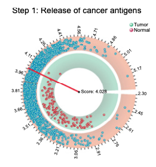

出自：https://aacrjournals.org/cancerres/article/78/23/6575/543748/TIP-A-Web-Server-for-Resolving-Tumor

图2. 特定BRCA样本（TCGA-A2-A0ST-01A-12R-A084-07）的免疫表型可视化。 C部分，六个环形图展示了该特定样本（红色指针）的抗癌免疫活性评分与TCGA BRCA数据库中所有肿瘤样本（外圈绿色点）和正常样本（内圈红色点）的对比结果。

Source: https://aacrjournals.org/cancerres/article/78/23/6575/543748/TIP-A-Web-Server-for-Resolving-Tumor

Figure 2. Visualization of immunophenotype for one specific BRCA sample, TCGA-A2-A0ST-01A-12R-A084-07. C, Six circular plots show the comparison of activity scores of anticancer immunity for this specific sample (red pointer) with those for all tumor (green points in outer circle) and normal (red points in inner circle) samples from TCGA BRCA data.

## 3 应用场景 Application scenarios

对比两个群体的数值分布，无需一一对应，可以用散点图展示。

我们在垂直坐标系中画过很多散点图，用不同颜色或形状分组。这次画成圆圈，用不同圆圈来分组。

Compare the numerical distributions between two groups without requiring one-to-one correspondence, which can be displayed using scatter plots.

We have previously created many scatter plots in vertical coordinate systems , using different colors or shapes for grouping. This time we will plot them as circles, using different circles for grouping.

## 4 环境设置 Requirements Description

```r
source("install_dependencies.R")
```

```
## Starting R package installation...
## ===========================================
##
## Installing Bioconductor packages...
## Package already installed: circlize
##
## ===========================================
## Package installation completed!
## You can now run your R scripts in this directory.
```

```r
library(circlize) # 用于绘制环形图 # For creating circular plots

# 显示英文报错信息
# Show English error messages
Sys.setenv(LANGUAGE = "en")

# 禁止chr转成factor
# Prevent character-to-factor conversion
options(stringsAsFactors = FALSE)
```

## 5 输入文件 Input Files

```r
# 加载模拟数据
# Loading simulated data
plot.data <- read.delim(file = "easy_input.txt",sep = "\t",row.names = NULL,header = T,check.names = F,stringsAsFactors = F)
head(plot.data)
```

```
##   sector     Value         y   Group
## 1   main  6.524683 0.3165117 Circle1
## 2   main 23.341915 0.6000470 Circle1
## 3   main 12.447757 0.5820994 Circle1
## 4   main 18.033462 0.4786531 Circle1
## 5   main  7.342389 0.6968041 Circle1
## 6   main 20.033142 0.4675009 Circle1
```

## 6 开始画图 Plotting

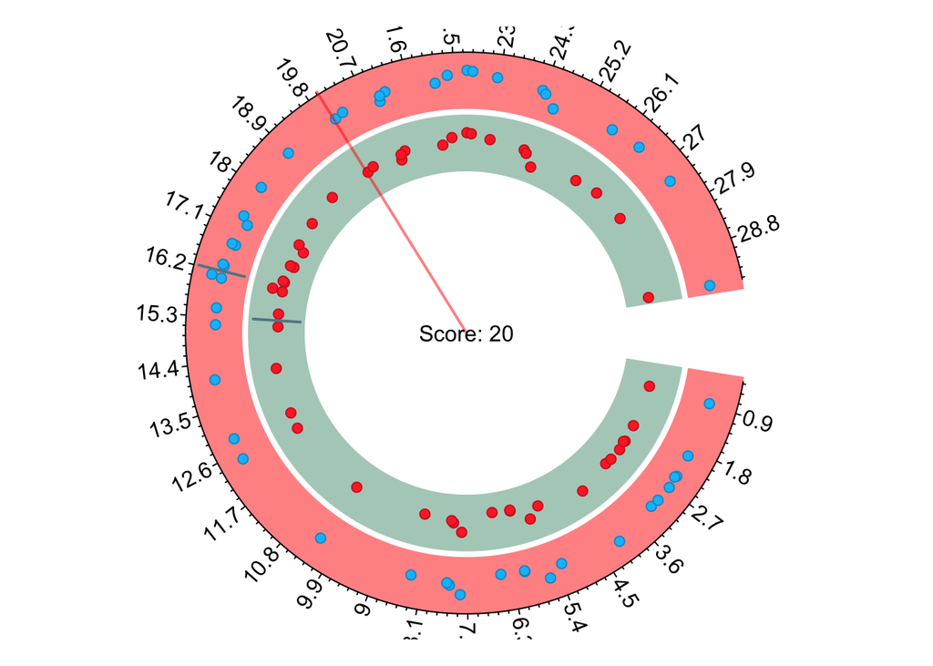

```r
# 设置参数
# Parameter settings
prop = 0.05
mark = 20

# 因子化分组变量
# Factorize group variable
plot.data$Group <- factor(plot.data$Group, levels = c("Circle1", "Circle2"))

# 生成绘图用数据
# Prepare plotting data
plot.region <- c(min(plot.data$Value), max(plot.data$Value))
plot.region <- rbind(plot.region, (plot.region-min(plot.region))*prop)
plot.data <- split(plot.data[, 1:3], plot.data$Group)

# 开始绘图
# Start Plotting
## 调整起始角度，以保证上下对称
## Adjust the starting angle to ensure top-bottom symmetry
deg.adjust <- 360 * 0.5 * prop
circos.par("start.degree" = 360-deg.adjust)
circos.initialize(sectors = c("main", "spare"), xlim = plot.region)

## 绘制第一环
## Draw first ring
# 绘制背景
# Draw background
draw.sector(deg.adjust, 360-deg.adjust,
            rou1 = 0.99, rou2 = 0.79, clock.wise = FALSE,
            col = "#FF000080", border = NA)

# 绘制数据点
# Plot data points
circos.track(sectors = plot.data[[1]]$sector,
             x = plot.data[[1]]$Value,
             y = plot.data[[1]]$y, panel.fun = function(x, y) {
               circos.points(x, y, col = "deepskyblue3", bg = "deepskyblue",
                             pch = 21, cex = 1.0)
             }, ylim = c(0, 1), bg.border = NA)

# 绘制中位数线
# Draw median line
circos.lines(rep(median(plot.data[[1]]$Value), 2), c(0, 1),
             sector.index = "main", track.index = 1,
             col = "#618895", lwd = 2)

## 绘制第二环
## Draw second ring
# 绘制背景
# Draw background
draw.sector(deg.adjust, 360-deg.adjust,
            rou1 = 0.77, rou2 = 0.57, clock.wise = FALSE,
            col = "#B1CFC3", border = NA)
# 绘制数据点
# Plot data points
circos.track(sectors = plot.data[[1]]$sector,
             x = plot.data[[1]]$Value,
             y = plot.data[[1]]$y, panel.fun = function(x, y) {
               circos.points(x, y, col = "firebrick3", bg = "firebrick1",
                             pch = 21, cex = 1.0)
             }, ylim = c(0, 1), bg.border = NA)

# 绘制中位数线
# Draw median line
circos.lines(rep(median(plot.data[[2]]$Value), 2), c(0, 1),
             sector.index = "main", track.index = 2,
             col = "#618895", lwd = 2)

## 绘制坐标轴
## Draw axis
circos.xaxis(sector.index = "main", track.index = 1, h = "top",
             labels.facing = "clockwise")

## 绘制特定数值标注线
## Draw specific value indicator
deg.mark <- get.cell.meta.data(name = "cell.xlim", sector.index = "main")
deg.range <- get.cell.meta.data(name = "xplot", sector.index = "main")
deg.mark <- deg.range[1] + (mark-deg.mark[1])*diff(deg.range)/diff(deg.mark)
draw.sector(deg.mark, deg.mark, rou1 = 1, rou2 = 0,
            border = "#FF000080", lwd = 2)

# 添加文字
# Add text
text(x = 0, y = 0, "Score: 20")
```

```r
# 清理环形布局
# Clear circular layout
circos.clear()

# 输出PDF
# Export PDF
dev.copy2pdf(file = "Circular.pdf", width = 7, height = 7)
```

## 7 后期修改 Post-processing

输出的pdf文件是矢量图，图中四边文字有遮挡，可以用Illustrator等矢量图编辑器打开，进行移动图形、放大画布、编辑文字等操作。

The output PDF file is a vector graphic. If text at the four edges is obscured, you can open it in vector graphic editing software like Illustrator to perform operations such as moving graphics, enlarging the canvas, and editing text.